# miRcore R session day 3 quiz.

Leonardo de Farias

2022-07-27

1. Create a bar graph. The values you use should be generated from a sampling of 20 to 50, pulling 6 times without replacement.
2. Add y axis label in the above graph. The y axis should be labeled “Number of Fans”
3. Add x axis label in the above graph. The x axis should be labeled “Ice Cream Flavor” and have 6 different flavors: chocolate, vanilla, strawberry, butter pecan, pistachio, and black cherry.
4. Give your graph a title.
5. In the above graph, the bars should be colored brown, white, pink, yellow, green, and purple.
6. In the above graph, there should be a legend.

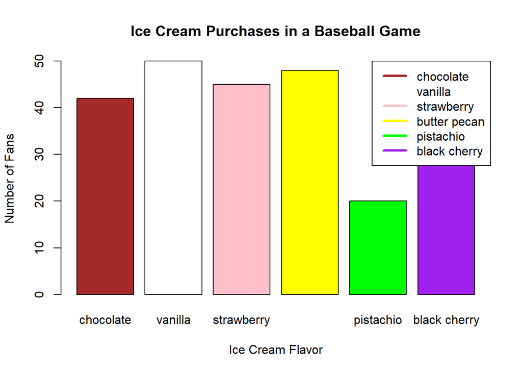

```r
colors <- c("brown", "white", "pink", "yellow", "green", "purple")
flavors <- c("chocolate", "vanilla", "strawberry", "butter pecan", "pistachio", "black cherry")
barplot(
  sample(20:50, 6, replace=F), main="Ice Cream Purchases in a Baseball Game",
  ylab="Number of Fans", xlab="Ice Cream Flavor",
  names.arg=flavors,
  col=colors
)
legend(x="topright",
       legend=flavors,
       col=colors,
       lwd=3)
```

9. Read smalldata again from “small_data.txt” file. for this Rmd file. Make sure you are in the right directory and file is there.

```r
###row.names=1 makes there not be miRNA as a feature, but rather an index
smalldata <- read.table("small_data.txt", header=TRUE, sep="\t", row.names=1)
head(smalldata)
```

```
##        Tumor_1  Tumor_2  Tumor_3  Tumor_4  Tumor_5  Tumor_6  Tumor_7  Tumor_8
## miR_a 57929.41 22506.07 34797.14 40623.09 94189.42 48033.67 86208.88 79334.63
## miR_b    35.39    34.11    30.16    43.27    33.21    38.34    18.80    34.52
## miR_c  1199.96  1524.17  1166.84   594.55  4366.68  2929.55  3268.03  3984.78
## miR_d    10.58     8.81     6.46     7.68    33.75    27.06    13.60    15.26
## miR_e   366.66   433.28   829.46   312.30  1595.39   553.11  1040.94  1054.47
## miR_f     4.01     5.20    12.50     2.29    30.68    45.91     4.80     6.69
##        Tumor_9  Tumor_10 Control_1 Control_2 Control_3 Control_4 Control_5
## miR_a 64407.79 107482.61 238305.30 355827.37 321015.59 189452.04 113086.64
## miR_b    22.87     60.79    108.39    107.48     84.09    145.38     29.36
## miR_c  2604.58   5391.68   8422.04   3025.42   6540.17  10951.75  15573.90
## miR_d    10.59     19.57     34.81     50.77     45.85     59.53     38.88
## miR_e   666.25   1892.86   2841.42   1504.25   3967.47   3645.77   3818.59
## miR_f     6.02     15.82     95.17    146.35     75.48    110.83    296.76
##       Control_6 Control_7 Control_8 Control_9 Control_10
## miR_a 299883.51 153344.45 212632.36 212525.33  149009.50
## miR_b     66.20    100.89    135.96    118.05     105.00
## miR_c  12967.52  10830.45   5188.23  11240.38    8873.80
## miR_d     48.51     34.12     44.45     31.65      52.90
## miR_e   4964.20   3798.18   1356.68   4924.02    8992.43
## miR_f     79.33     36.50    159.97     30.16      99.39
```

10. Make a scatter plot. The values should be pulled from the small dataset, x being Tumor_5 and y being Control_5.
11. Label the axis appropriately, and give your graph a title of your choice.
12. Add blue color to the scatter plot.

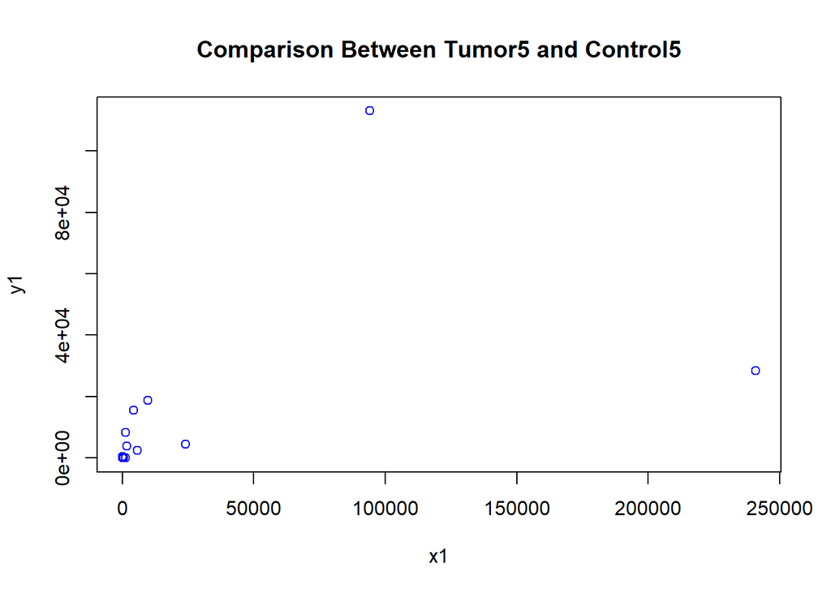

```r
x1 <- smalldata$Tumor_5
y1 <- smalldata$Control_5
plot(x1, y1, main="Comparison Between Tumor5 and Control5", col="blue")
```

13. Save the above Rmd as a “R day 3.Rmd” file.